# Aprendizaje No Supervisado

RLadies_Medellin

23/11/2022

[figure not shown]

## **Diferencias entre Aprendizaje Supervisado y No Supervisado**

Los algoritmos de aprendizaje **supervisado** basan su aprendizaje en un juego de datos de entrenamiento previamente etiquetados. Esto le permitirá al algoritmo poder “aprender” una función capaz de predecir el atributo objetivo para un juego de datos nuevo. Las dos grandes familias de algoritmos supervisados son: los algoritmos de regresión cuando el resultado a predecir es un atributo numérico y los algoritmos de clasificación cuando el resultado a predecir es un atributo categórico.

Los métodos **no supervisados (unsupervised methods)** son algoritmos que basan su proceso de entrenamiento en un juego de datos sin etiquetas o clases previamente deﬁnidas.El aprendizaje no supervisado está dedicado a las tareas de agrupamiento, también llamadas clustering o segmentación, donde su objetivo es encontrar grupos similares en el conjunto de datos. Existen dos grupos principales de métodos o algoritmos de agrupamiento: los métodos jerárquicos y los métodos particionales o no jerárquicos.

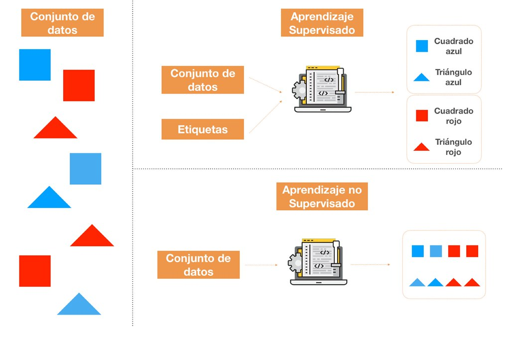

Las principales diferencias entre el aprendizaje **supervisado** y el aprendizaje **no supervisado** son las siguientes:

- La necesidad de *datos etiquetados* en el aprendizaje automático **supervisado**.
- El *modelo* que se utiliza para solucionar un problema. El aprendizaje automático **supervisado** generalmente se usa para clasificar datos o hacer predicciones, mientras que el aprendizaje **no supervisado** generalmente se usa para comprender las relaciones dentro de los conjuntos de datos.
- El aprendizaje automático **supervisado** requiere muchos más *recursos* debido a la necesidad de datos etiquetados.

## **Clustering**

Clustering es un proceso similar al de *clasificación*, pero con un fundamento diferente. En el Clustering no sabes cuales categorias estas buscando, si no que intentas crear una segmentación de tus propios datos en grupos más o menos homogéneos. Cuando utilizamos algoritmos de clustering en el data set, surgen de entre los datos cosas inesperadas como estructuras, clusters o agrupaciones que un humano no se habría imaginado pero la máquina crea por nosotros.

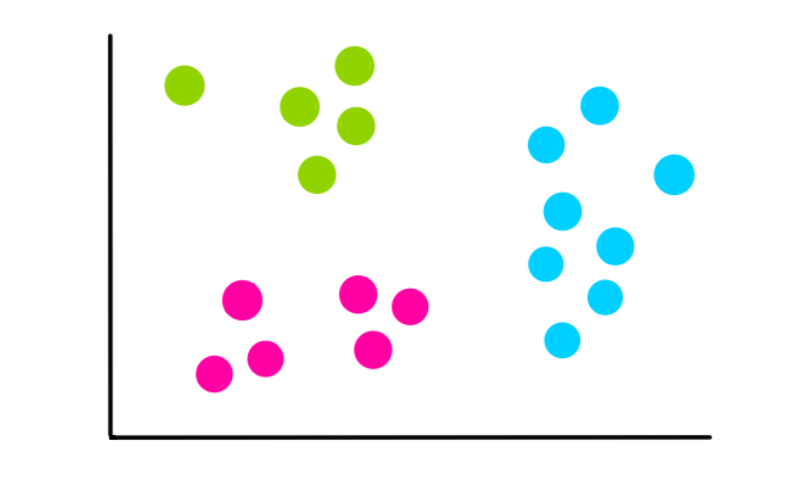

## **K-Means**

K-means agrupa objetos en k grupos basándose en sus características. El agrupamiento se realiza minimizando la suma de distancias entre cada objeto y el centroide de su grupo o cluster. Se suele usar la distancia cuadrática.

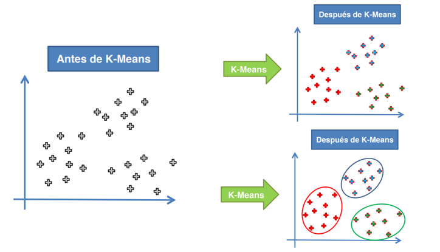

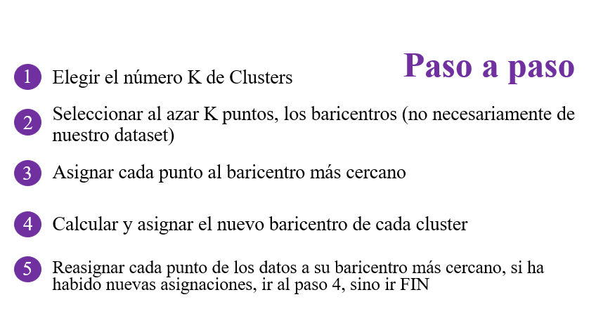

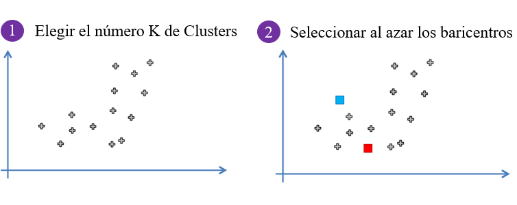

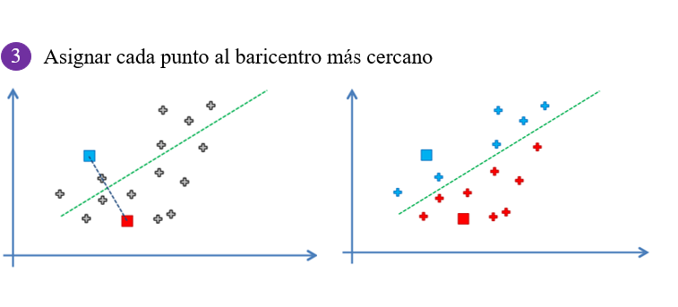

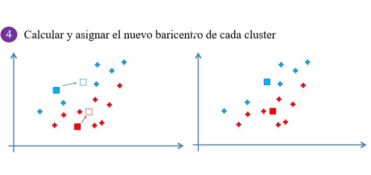

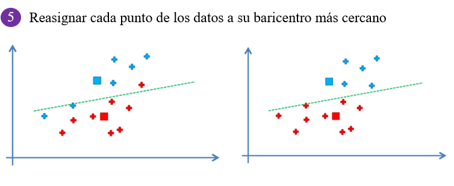

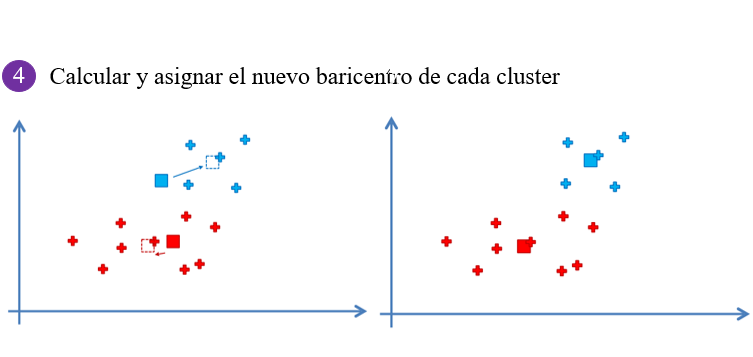

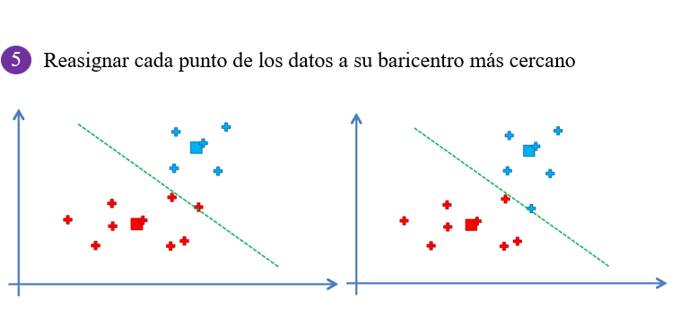

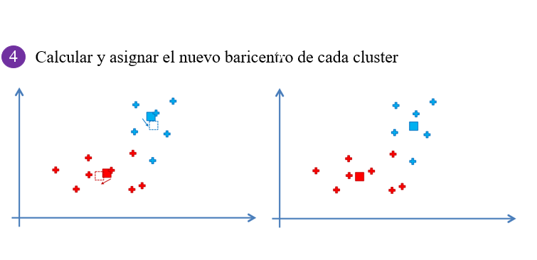

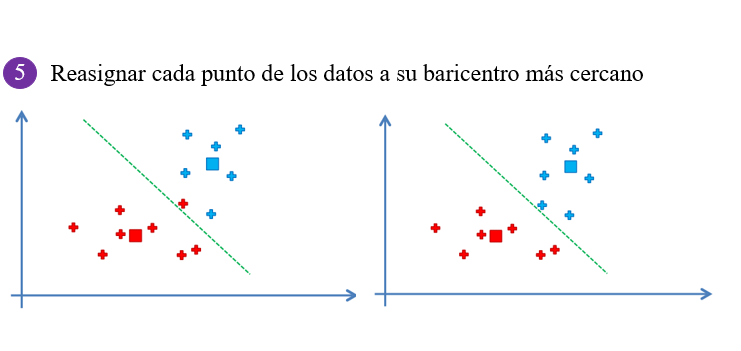

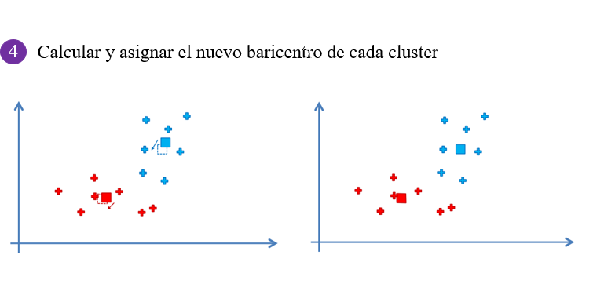

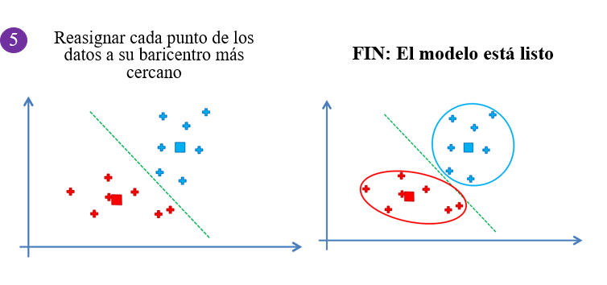

## **K-Means: La trampa de la inicialización aleatoria**

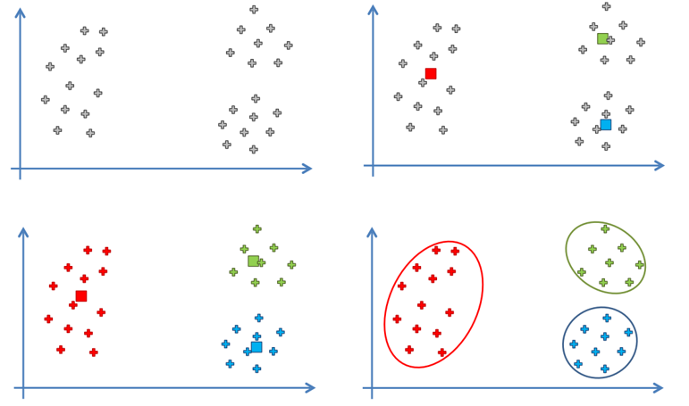

*¿Y qué pasaría si elegimos una mala inicialización aleatoria del baricentro?*

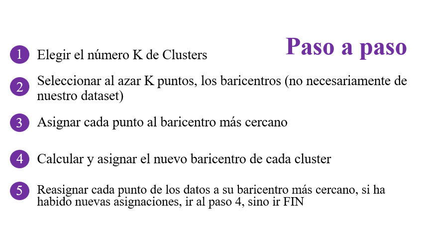

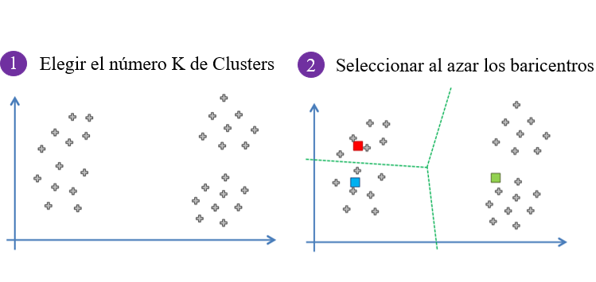

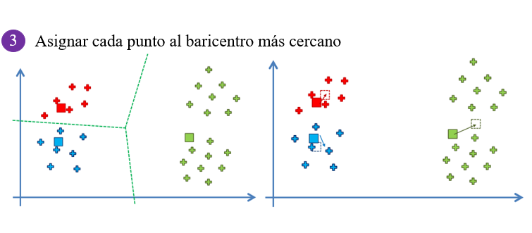

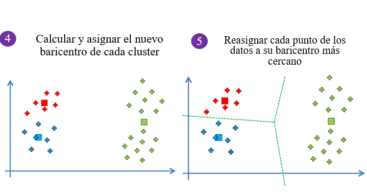

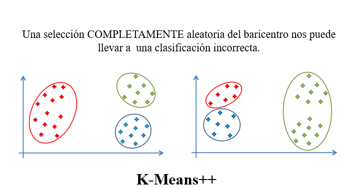

## **K-Means: ¿Cómo elegir el número correcto de clusters?**

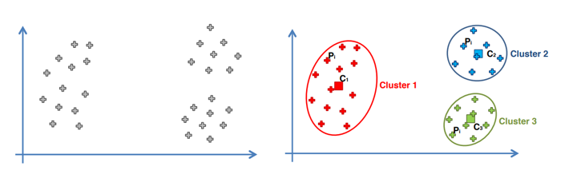

La Suma de los Cuadrados de los Centros de los Clusters **WCSS (Within Cluster Sum of Squares)** representa una solución para la selección adecuada del número de clusters.

$$WCSS = \sum_{P_i \in Cluster 1} d(P_i, C_1)^2 + \sum_{P_i \in Cluster 2} d(P_i, C_2)^2 + \sum_{P_i \in Cluster 3} d(P_i, C_3)^2$$

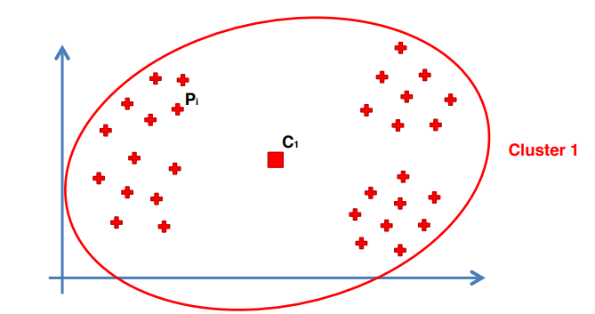

$$WCSS = \sum_{P_i \in Cluster 1} d(P_i, C_1)^2$$

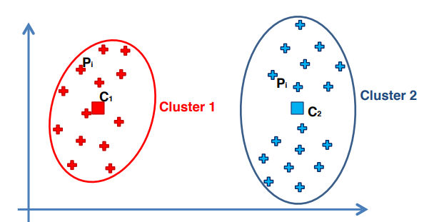

$$WCSS = \sum_{P_i \in Cluster 1} d(P_i, C_1)^2 + \sum_{P_i \in Cluster 2} d(P_i, C_2)^2$$

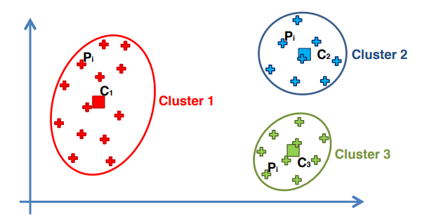

$$WCSS = \sum_{P_i \in Cluster 1} d(P_i, C_1)^2 + \sum_{P_i \in Cluster 2} d(P_i, C_2)^2 + \sum_{P_i \in Cluster 3} d(P_i, C_3)^2$$

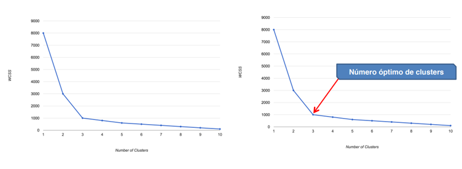

## **K-Means: Aplicación**

[figure not shown]

```r
# Clustering con K-means
# Importar los datos
dataset = read.csv('Mall_Customers.csv')
head(dataset)
```

```
##   CustomerID  Genre Age Annual.Income..k.. Spending.Score..1.100.
## 1          1   Male  19                 15                     39
## 2          2   Male  21                 15                     81
## 3          3 Female  20                 16                      6
## 4          4 Female  23                 16                     77
## 5          5 Female  31                 17                     40
## 6          6 Female  22                 17                     76
```

```r
# Selección variables de interés
X = dataset[, 4:5]
```

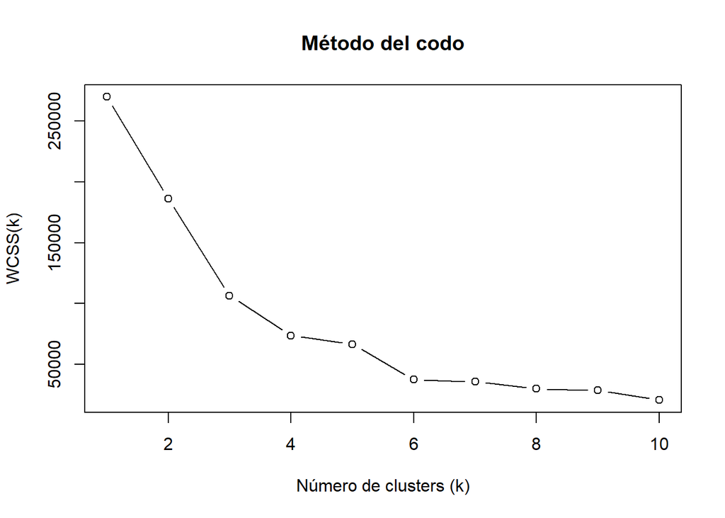

```r
# Método del codo
set.seed(6)
wcss = vector()
for (i in 1:10){
  wcss[i] <- sum(kmeans(X, i)$withinss)
}
plot(1:10, wcss, type = 'b', main = "Método del codo",
     xlab = "Número de clusters (k)", ylab = "WCSS(k)")
```

```r
# Aplicar el algoritmo de k-means con k optimo
set.seed(29)
kmeans <- kmeans(X, 5, iter.max = 300, nstart = 10)
```

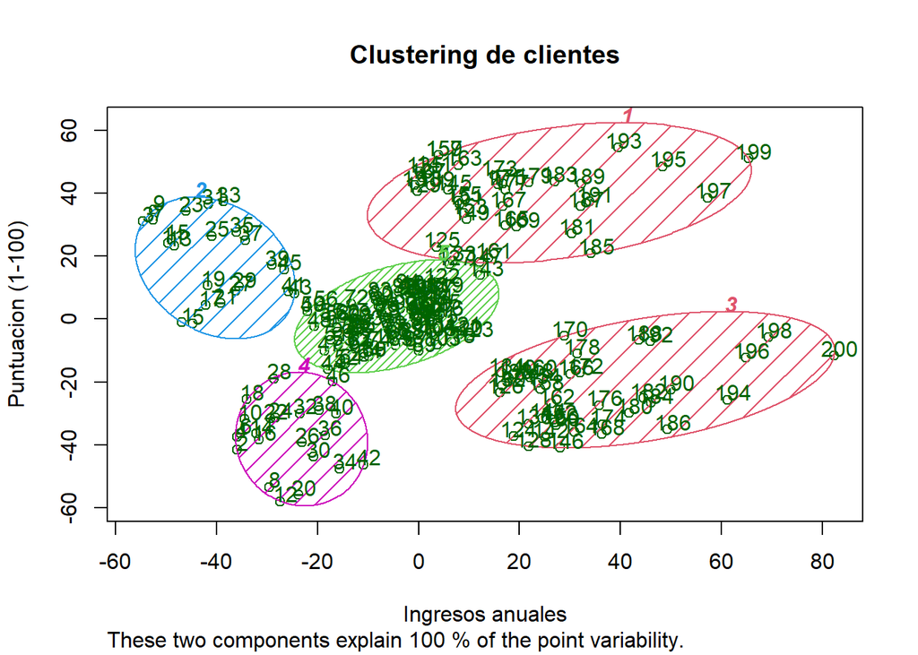

```r
#Visualizacion de los clusters
#install.packages("cluster")
library(cluster)
clusplot(X,
         kmeans$cluster,
         lines = 0,
         shade = TRUE,
         color = TRUE,
         labels = 2,
         plotchar = FALSE,
         span = TRUE,
         main = "Clustering de clientes",
         xlab = "Ingresos anuales",
         ylab = "Puntuacion (1-100)"
         )
```

## **Clustering Jerárquico**

Es un método de análisis de grupos puntuales, que busca construir una jerarquía de grupos entre los elementos analizados.

Este método trata de crear grupos de elementos homogéneos entre sí y heterogéneos entre grupos, para conseguirlo principalmente se puede hacer mediante estrategia aglomerativa o divisitiva.

El agrupamiento jerárquico es capaz de fijar por si solo el número de clusters, por ello se puede utilizar de forma exploratoria y posteriormente aplicar un análisis no jerárquico con el número de clusters obtenido.

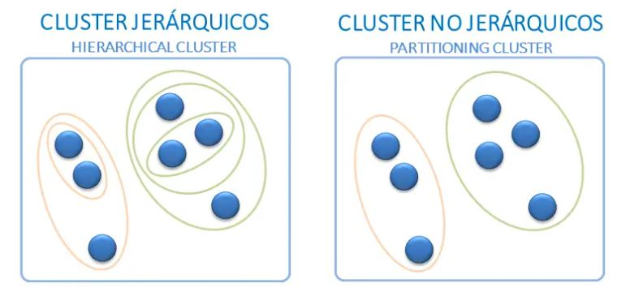

Los métodos **Jerárquicos** se dividen en dos grupos

**Agglomerative clustering (bottom-up):** el agrupamiento se inicia en la base del árbol, donde cada observación forma un cluster individual. Los clusters se van combinado a medida que la estructura crece hasta converger en una única “rama” central.

**Divisive clustering (top-down):** es la estrategia opuesta al agglomerative clustering, se inicia con todas las observaciones contenidas en un mismo cluster y luego suceden divisiones hasta que cada observación forma un cluster individual.

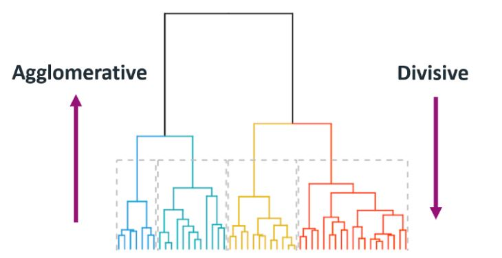

## **Agglomerative**

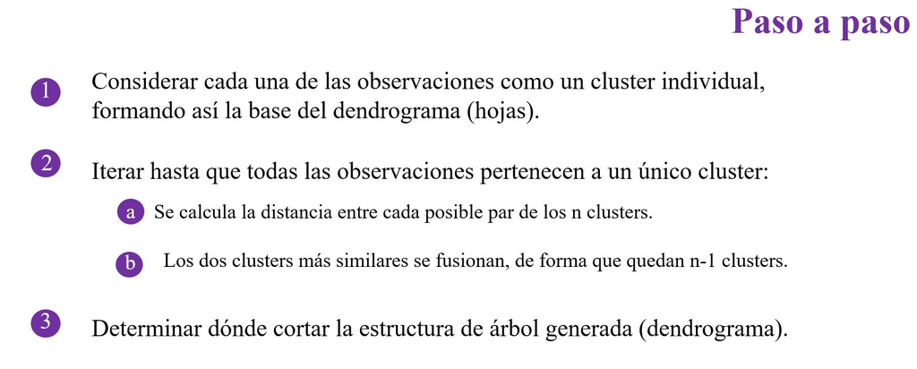